# Capstone 4th Economy

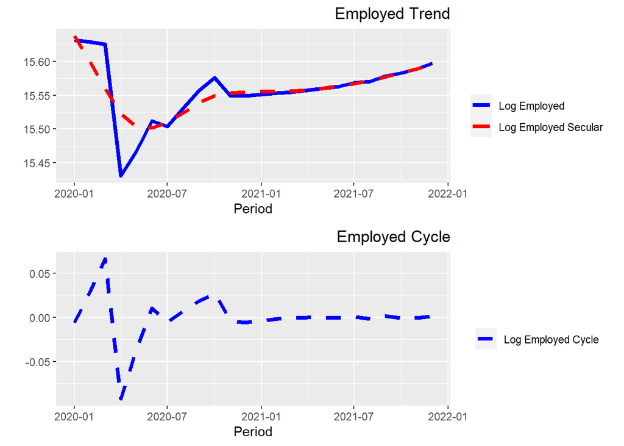

```r
plot_grid(plot63, plot64,ncol = 1,align = 'v')
```

#KANSAS

```r
lf_states20 <- filter(lf_states, Year != 2019, State == 20, early == 0)
lf_states20_6.25 <- hpfilter(lf_states20$lEmp , freq = 6.25,type = "lambda")
lf_states20$Emp_T6.25 <- lf_states20_6.25$trend
lf_states20$Emp_C6.25 <- lf_states20_6.25$cycle
plot65<-ggplot(data=lf_states20)+
geom_line(aes(x=Period,y=lEmp,color='Log Employed'),size=1.5) + geom_line(aes(x=Period,y=Emp_T6.25,color='Log Employed Secular'),linetype=2,size=1.5) +xlab("Period")+ylab("")+scale_colour_manual(name="",values=c('Log Employed'='blue','Log Employed Secular'='red'))+ggtitle('Employed Trend')+theme(plot.title = element_text(hjust = 1))

plot66<-ggplot(data=lf_states20)+
geom_line(aes(x=Period,y=Emp_C6.25,color='Log Employed Cycle'),size=1.5,linetype=2)  +xlab("Period")+ylab("")+scale_colour_manual(name="",values=c('Log Employed Cycle'='blue'))+ggtitle('Employed Cycle')+theme(plot.title = element_text(hjust = 1))
```

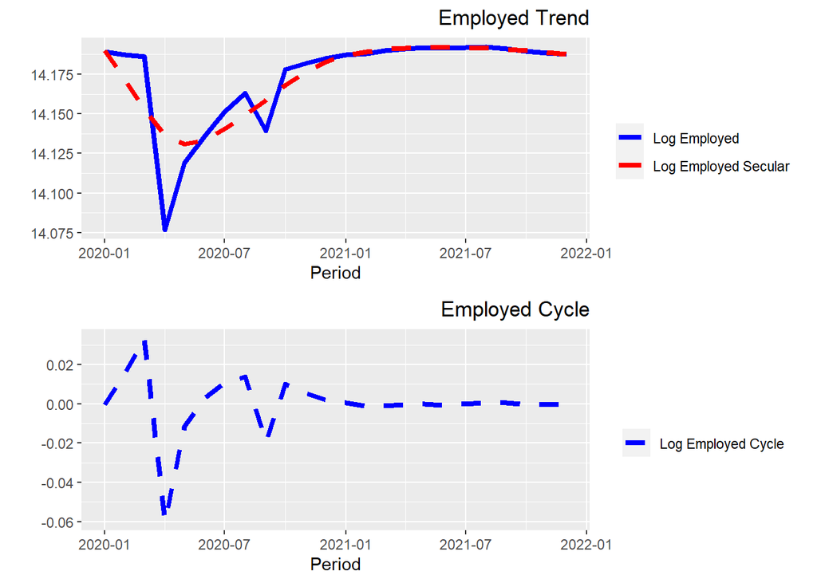

```r
plot_grid(plot65, plot66,ncol = 1,align = 'v')
```

#KENTUCKY

```r
lf_states21 <- filter(lf_states, Year != 2019, State == 21, early == 0)
lf_states21_6.25 <- hpfilter(lf_states21$lEmp , freq = 6.25,type = "lambda")
lf_states21$Emp_T6.25 <- lf_states21_6.25$trend
lf_states21$Emp_C6.25 <- lf_states21_6.25$cycle
plot67<-ggplot(data=lf_states21)+
geom_line(aes(x=Period,y=lEmp,color='Log Employed'),size=1.5) + geom_line(aes(x=Period,y=Emp_T6.25,color='Log Employed Secular'),linetype=2,size=1.5) +xlab("Period")+ylab("")+scale_colour_manual(name="",values=c('Log Employed'='blue','Log Employed Secular'='red'))+ggtitle('Employed Trend')+theme(plot.title = element_text(hjust = 1))

plot68<-ggplot(data=lf_states21)+
geom_line(aes(x=Period,y=Emp_C6.25,color='Log Employed Cycle'),size=1.5,linetype=2)  +xlab("Period")+ylab("")+scale_colour_manual(name="",values=c('Log Employed Cycle'='blue'))+ggtitle('Employed Cycle')+theme(plot.title = element_text(hjust = 1))
```

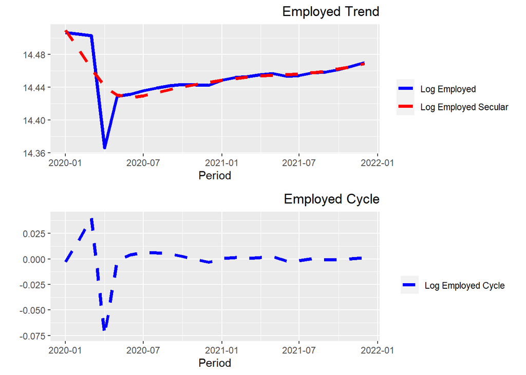

```r
plot_grid(plot67, plot68,ncol = 1,align = 'v')
```

#LOUISIANA

```r
lf_states22 <- filter(lf_states, Year != 2019, State == 22, early == 0)
lf_states22_6.25 <- hpfilter(lf_states22$lEmp , freq = 6.25,type = "lambda")
lf_states22$Emp_T6.25 <- lf_states22_6.25$trend
lf_states22$Emp_C6.25 <- lf_states22_6.25$cycle
plot69<-ggplot(data=lf_states22)+
geom_line(aes(x=Period,y=lEmp,color='Log Employed'),size=1.5) + geom_line(aes(x=Period,y=Emp_T6.25,color='Log Employed Secular'),linetype=2,size=1.5) +xlab("Period")+ylab("")+scale_colour_manual(name="",values=c('Log Employed'='blue','Log Employed Secular'='red'))+ggtitle('Employed Trend')+theme(plot.title = element_text(hjust = 1))

plot70<-ggplot(data=lf_states22)+
geom_line(aes(x=Period,y=Emp_C6.25,color='Log Employed Cycle'),size=1.5,linetype=2)  +xlab("Period")+ylab("")+scale_colour_manual(name="",values=c('Log Employed Cycle'='blue'))+ggtitle('Employed Cycle')+theme(plot.title = element_text(hjust = 1))
```

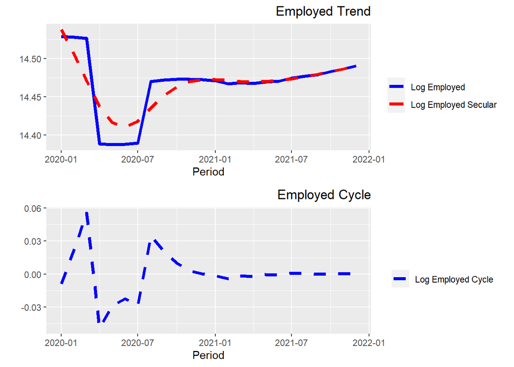

```r
plot_grid(plot69, plot70,ncol = 1,align = 'v')
```

#MAINE

```r
lf_states23 <- filter(lf_states, Year != 2019, State == 23, early == 0)
lf_states23_6.25 <- hpfilter(lf_states23$lEmp , freq = 6.25,type = "lambda")
lf_states23$Emp_T6.25 <- lf_states23_6.25$trend
lf_states23$Emp_C6.25 <- lf_states23_6.25$cycle
plot71<-ggplot(data=lf_states23)+
geom_line(aes(x=Period,y=lEmp,color='Log Employed'),size=1.5) + geom_line(aes(x=Period,y=Emp_T6.25,color='Log Employed Secular'),linetype=2,size=1.5) +xlab("Period")+ylab("")+scale_colour_manual(name="",values=c('Log Employed'='blue','Log Employed Secular'='red'))+ggtitle('Employed Trend')+theme(plot.title = element_text(hjust = 1))

plot72<-ggplot(data=lf_states23)+
geom_line(aes(x=Period,y=Emp_C6.25,color='Log Employed Cycle'),size=1.5,linetype=2)  +xlab("Period")+ylab("")+scale_colour_manual(name="",values=c('Log Employed Cycle'='blue'))+ggtitle('Employed Cycle')+theme(plot.title = element_text(hjust = 1))
```

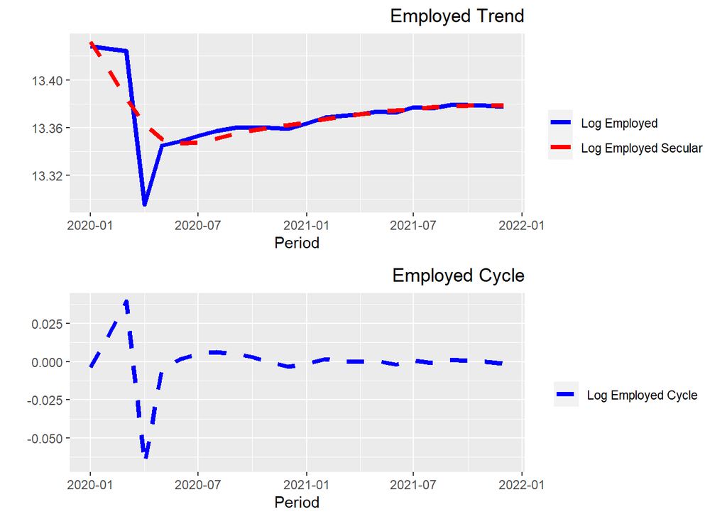

```r
plot_grid(plot71, plot72,ncol = 1,align = 'v')
```

#MASSACHUSETTS

```r
lf_states25 <- filter(lf_states, Year != 2019, State == 25, early == 0)
lf_states25_6.25 <- hpfilter(lf_states25$lEmp , freq = 6.25,type = "lambda")
lf_states25$Emp_T6.25 <- lf_states25_6.25$trend
lf_states25$Emp_C6.25 <- lf_states25_6.25$cycle
plot73<-ggplot(data=lf_states25)+
geom_line(aes(x=Period,y=lEmp,color='Log Employed'),size=1.5) + geom_line(aes(x=Period,y=Emp_T6.25,color='Log Employed Secular'),linetype=2,size=1.5) +xlab("Period")+ylab("")+scale_colour_manual(name="",values=c('Log Employed'='blue','Log Employed Secular'='red'))+ggtitle('Employed Trend')+theme(plot.title = element_text(hjust = 1))

plot74<-ggplot(data=lf_states25)+
geom_line(aes(x=Period,y=Emp_C6.25,color='Log Employed Cycle'),size=1.5,linetype=2)  +xlab("Period")+ylab("")+scale_colour_manual(name="",values=c('Log Employed Cycle'='blue'))+ggtitle('Employed Cycle')+theme(plot.title = element_text(hjust = 1))
```

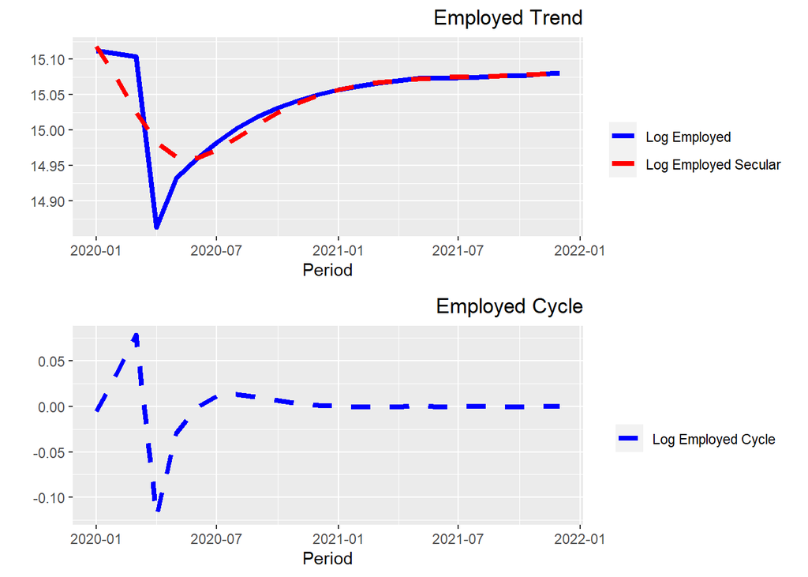

```r
plot_grid(plot73, plot74,ncol = 1,align = 'v')
```

#MICHIGAN

```r
lf_states26 <- filter(lf_states, Year != 2019, State == 26, early == 0)
lf_states26_6.25 <- hpfilter(lf_states26$lEmp , freq = 6.25,type = "lambda")
lf_states26$Emp_T6.25 <- lf_states26_6.25$trend
lf_states26$Emp_C6.25 <- lf_states26_6.25$cycle
plot75<-ggplot(data=lf_states26)+
geom_line(aes(x=Period,y=lEmp,color='Log Employed'),size=1.5) + geom_line(aes(x=Period,y=Emp_T6.25,color='Log Employed Secular'),linetype=2,size=1.5) +xlab("Period")+ylab("")+scale_colour_manual(name="",values=c('Log Employed'='blue','Log Employed Secular'='red'))+ggtitle('Employed Trend')+theme(plot.title = element_text(hjust = 1))

plot76<-ggplot(data=lf_states26)+
geom_line(aes(x=Period,y=Emp_C6.25,color='Log Employed Cycle'),size=1.5,linetype=2)  +xlab("Period")+ylab("")+scale_colour_manual(name="",values=c('Log Employed Cycle'='blue'))+ggtitle('Employed Cycle')+theme(plot.title = element_text(hjust = 1))
```

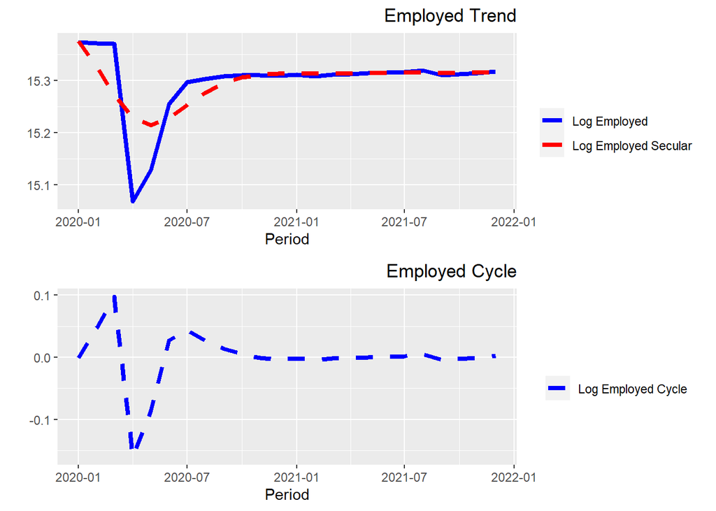

```r
plot_grid(plot75, plot76,ncol = 1,align = 'v')
```

#MINNESOTA

```r
lf_states27 <- filter(lf_states, Year != 2019, State == 27, early == 0)
lf_states27_6.25 <- hpfilter(lf_states27$lEmp , freq = 6.25,type = "lambda")
lf_states27$Emp_T6.25 <- lf_states27_6.25$trend
lf_states27$Emp_C6.25 <- lf_states27_6.25$cycle
plot77<-ggplot(data=lf_states27)+
geom_line(aes(x=Period,y=lEmp,color='Log Employed'),size=1.5) + geom_line(aes(x=Period,y=Emp_T6.25,color='Log Employed Secular'),linetype=2,size=1.5) +xlab("Period")+ylab("")+scale_colour_manual(name="",values=c('Log Employed'='blue','Log Employed Secular'='red'))+ggtitle('Employed Trend')+theme(plot.title = element_text(hjust = 1))

plot78<-ggplot(data=lf_states27)+
geom_line(aes(x=Period,y=Emp_C6.25,color='Log Employed Cycle'),size=1.5,linetype=2)  +xlab("Period")+ylab("")+scale_colour_manual(name="",values=c('Log Employed Cycle'='blue'))+ggtitle('Employed Cycle')+theme(plot.title = element_text(hjust = 1))
```

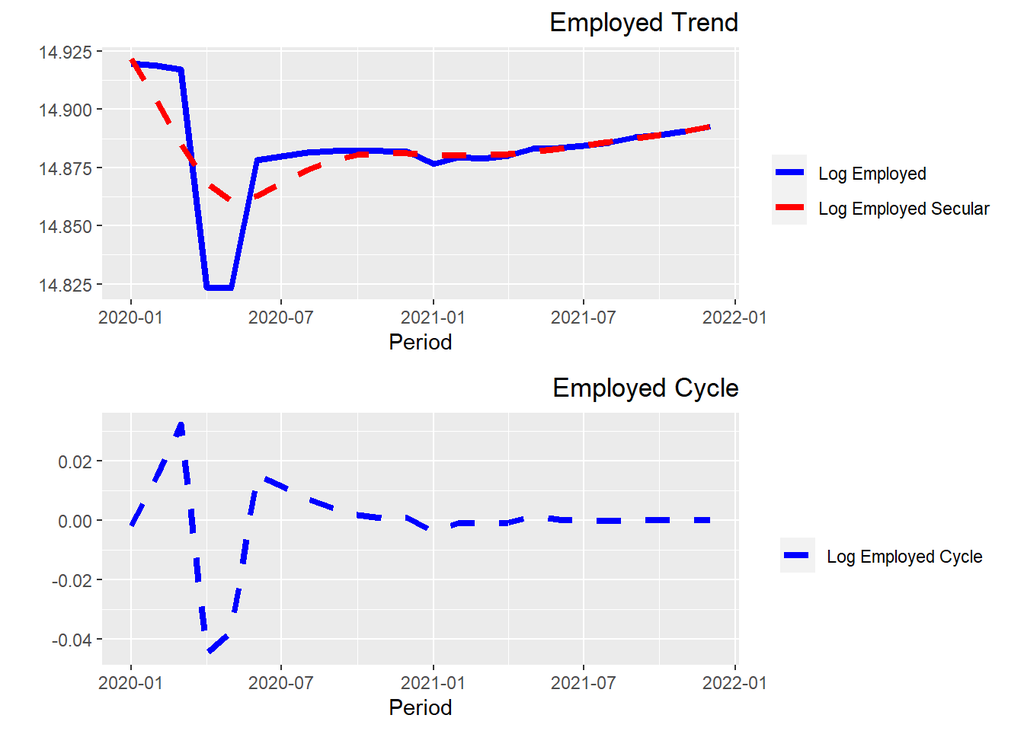

```r
plot_grid(plot77, plot78,ncol = 1,align = 'v')
```

#NEVADA

```r
lf_states32 <- filter(lf_states, Year != 2019, State == 32, early == 0)
lf_states32_6.25 <- hpfilter(lf_states32$lEmp , freq = 6.25,type = "lambda")
lf_states32$Emp_T6.25 <- lf_states32_6.25$trend
lf_states32$Emp_C6.25 <- lf_states32_6.25$cycle
plot79<-ggplot(data=lf_states32)+
geom_line(aes(x=Period,y=lEmp,color='Log Employed'),size=1.5) + geom_line(aes(x=Period,y=Emp_T6.25,color='Log Employed Secular'),linetype=2,size=1.5) +xlab("Period")+ylab("")+scale_colour_manual(name="",values=c('Log Employed'='blue','Log Employed Secular'='red'))+ggtitle('Employed Trend')+theme(plot.title = element_text(hjust = 1))

plot80<-ggplot(data=lf_states32)+
geom_line(aes(x=Period,y=Emp_C6.25,color='Log Employed Cycle'),size=1.5,linetype=2)  +xlab("Period")+ylab("")+scale_colour_manual(name="",values=c('Log Employed Cycle'='blue'))+ggtitle('Employed Cycle')+theme(plot.title = element_text(hjust = 1))
```

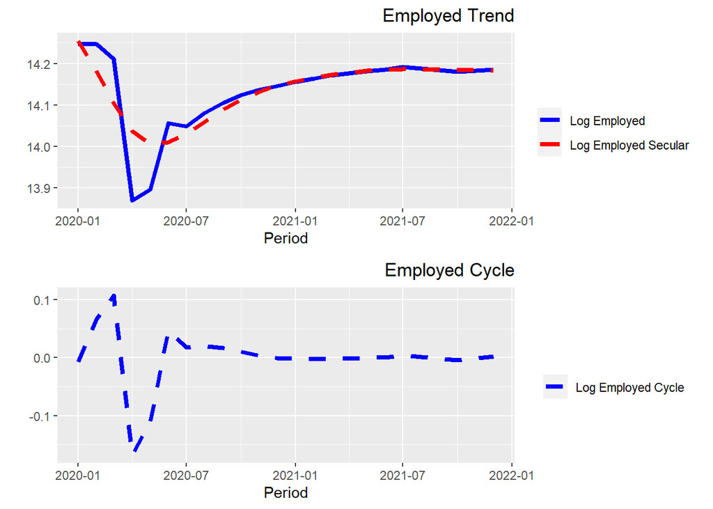

```r
plot_grid(plot79, plot80,ncol = 1,align = 'v')
```

#NEW JERSEY

```r
lf_states34 <- filter(lf_states, Year != 2019, State == 34, early == 0)
lf_states34_6.25 <- hpfilter(lf_states34$lEmp , freq = 6.25,type = "lambda")
lf_states34$Emp_T6.25 <- lf_states34_6.25$trend
lf_states34$Emp_C6.25 <- lf_states34_6.25$cycle
plot81<-ggplot(data=lf_states34)+
geom_line(aes(x=Period,y=lEmp,color='Log Employed'),size=1.5) + geom_line(aes(x=Period,y=Emp_T6.25,color='Log Employed Secular'),linetype=2,size=1.5) +xlab("Period")+ylab("")+scale_colour_manual(name="",values=c('Log Employed'='blue','Log Employed Secular'='red'))+ggtitle('Employed Trend')+theme(plot.title = element_text(hjust = 1))

plot82<-ggplot(data=lf_states34)+
geom_line(aes(x=Period,y=Emp_C6.25,color='Log Employed Cycle'),size=1.5,linetype=2)  +xlab("Period")+ylab("")+scale_colour_manual(name="",values=c('Log Employed Cycle'='blue'))+ggtitle('Employed Cycle')+theme(plot.title = element_text(hjust = 1))
```

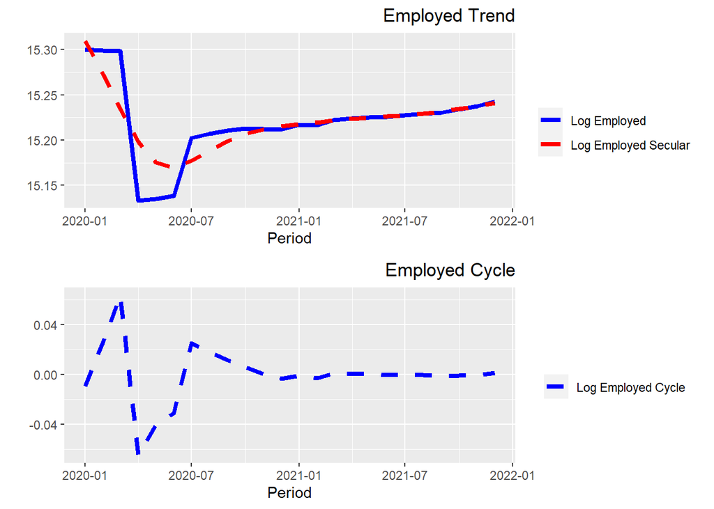

```r
plot_grid(plot81, plot82,ncol = 1,align = 'v')
```

#NEW MEXICO

```r
lf_states35 <- filter(lf_states, Year != 2019, State == 35, early == 0)
lf_states35_6.25 <- hpfilter(lf_states35$lEmp , freq = 6.25,type = "lambda")
lf_states35$Emp_T6.25 <- lf_states35_6.25$trend
lf_states35$Emp_C6.25 <- lf_states35_6.25$cycle
plot83<-ggplot(data=lf_states35)+
geom_line(aes(x=Period,y=lEmp,color='Log Employed'),size=1.5) + geom_line(aes(x=Period,y=Emp_T6.25,color='Log Employed Secular'),linetype=2,size=1.5) +xlab("Period")+ylab("")+scale_colour_manual(name="",values=c('Log Employed'='blue','Log Employed Secular'='red'))+ggtitle('Employed Trend')+theme(plot.title = element_text(hjust = 1))

plot84<-ggplot(data=lf_states35)+
geom_line(aes(x=Period,y=Emp_C6.25,color='Log Employed Cycle'),size=1.5,linetype=2)  +xlab("Period")+ylab("")+scale_colour_manual(name="",values=c('Log Employed Cycle'='blue'))+ggtitle('Employed Cycle')+theme(plot.title = element_text(hjust = 1))
```

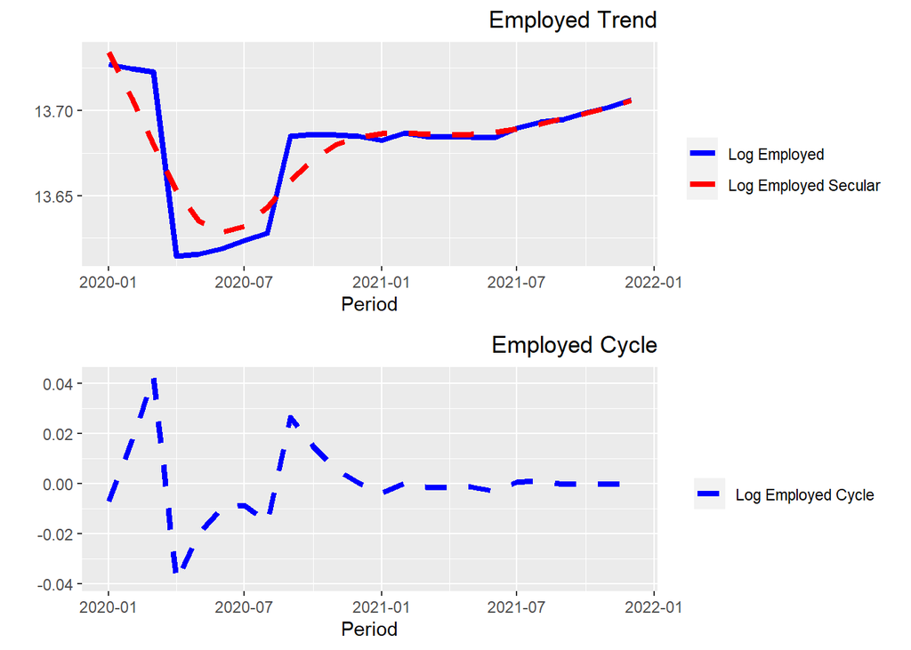

```r
plot_grid(plot83, plot84,ncol = 1,align = 'v')
```

#NEW YORK

```r
lf_states36 <- filter(lf_states, Year != 2019, State == 36, early == 0)
lf_states36_6.25 <- hpfilter(lf_states36$lEmp , freq = 6.25,type = "lambda")
lf_states36$Emp_T6.25 <- lf_states36_6.25$trend
lf_states36$Emp_C6.25 <- lf_states36_6.25$cycle
plot85<-ggplot(data=lf_states36)+
geom_line(aes(x=Period,y=lEmp,color='Log Employed'),size=1.5) + geom_line(aes(x=Period,y=Emp_T6.25,color='Log Employed Secular'),linetype=2,size=1.5) +xlab("Period")+ylab("")+scale_colour_manual(name="",values=c('Log Employed'='blue','Log Employed Secular'='red'))+ggtitle('Employed Trend')+theme(plot.title = element_text(hjust = 1))

plot86<-ggplot(data=lf_states36)+
geom_line(aes(x=Period,y=Emp_C6.25,color='Log Employed Cycle'),size=1.5,linetype=2)  +xlab("Period")+ylab("")+scale_colour_manual(name="",values=c('Log Employed Cycle'='blue'))+ggtitle('Employed Cycle')+theme(plot.title = element_text(hjust = 1))
```

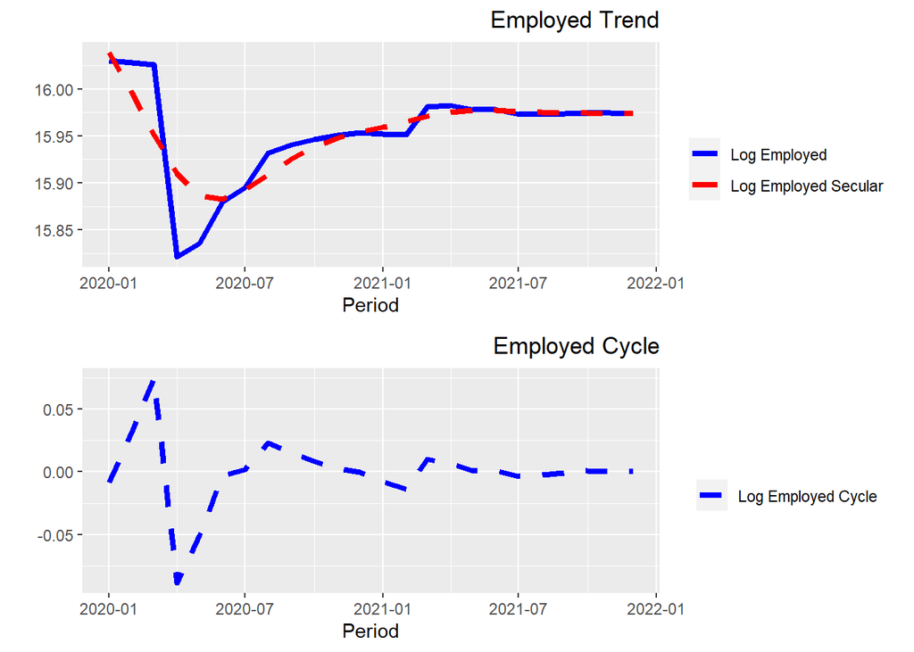

```r
plot_grid(plot85, plot86,ncol = 1,align = 'v')
```

#NORTH CAROLINA

```r
lf_states37 <- filter(lf_states, Year != 2019, State == 37, early == 0)
lf_states37_6.25 <- hpfilter(lf_states37$lEmp , freq = 6.25,type = "lambda")
lf_states37$Emp_T6.25 <- lf_states37_6.25$trend
lf_states37$Emp_C6.25 <- lf_states37_6.25$cycle
plot87<-ggplot(data=lf_states37)+
geom_line(aes(x=Period,y=lEmp,color='Log Employed'),size=1.5) + geom_line(aes(x=Period,y=Emp_T6.25,color='Log Employed Secular'),linetype=2,size=1.5) +xlab("Period")+ylab("")+scale_colour_manual(name="",values=c('Log Employed'='blue','Log Employed Secular'='red'))+ggtitle('Employed Trend')+theme(plot.title = element_text(hjust = 1))

plot88<-ggplot(data=lf_states37)+
geom_line(aes(x=Period,y=Emp_C6.25,color='Log Employed Cycle'),size=1.5,linetype=2)  +xlab("Period")+ylab("")+scale_colour_manual(name="",values=c('Log Employed Cycle'='blue'))+ggtitle('Employed Cycle')+theme(plot.title = element_text(hjust = 1))
```

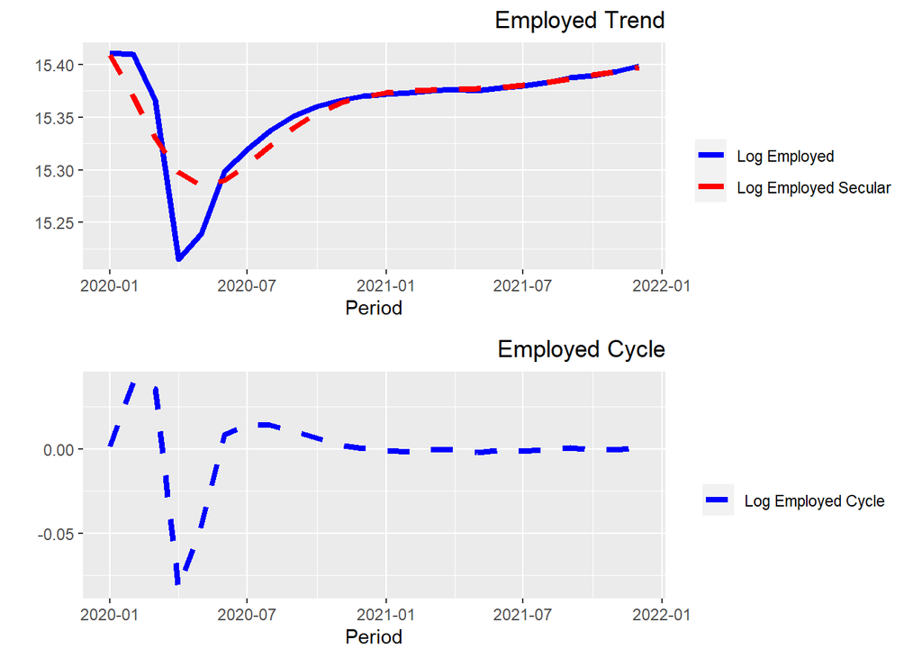

```r
plot_grid(plot87, plot88,ncol = 1,align = 'v')
```

#OREGON

```r
lf_states41 <- filter(lf_states, Year != 2019, State == 41, early == 0)
lf_states41_6.25 <- hpfilter(lf_states41$lEmp , freq = 6.25,type = "lambda")
lf_states41$Emp_T6.25 <- lf_states41_6.25$trend
lf_states41$Emp_C6.25 <- lf_states41_6.25$cycle
plot89<-ggplot(data=lf_states41)+
geom_line(aes(x=Period,y=lEmp,color='Log Employed'),size=1.5) + geom_line(aes(x=Period,y=Emp_T6.25,color='Log Employed Secular'),linetype=2,size=1.5) +xlab("Period")+ylab("")+scale_colour_manual(name="",values=c('Log Employed'='blue','Log Employed Secular'='red'))+ggtitle('Employed Trend')+theme(plot.title = element_text(hjust = 1))

plot90<-ggplot(data=lf_states41)+
geom_line(aes(x=Period,y=Emp_C6.25,color='Log Employed Cycle'),size=1.5,linetype=2)  +xlab("Period")+ylab("")+scale_colour_manual(name="",values=c('Log Employed Cycle'='blue'))+ggtitle('Employed Cycle')+theme(plot.title = element_text(hjust = 1))
```

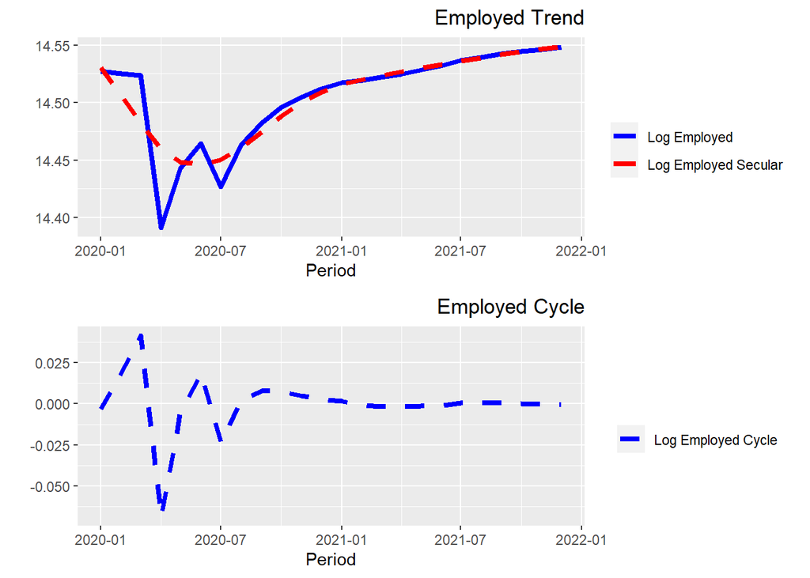

```r
plot_grid(plot89, plot90,ncol = 1,align = 'v')
```

#PENNSYLVANIA

```r
lf_states42 <- filter(lf_states, Year != 2019, State == 42, early == 0)
lf_states42_6.25 <- hpfilter(lf_states42$lEmp , freq = 6.25,type = "lambda")
lf_states42$Emp_T6.25 <- lf_states42_6.25$trend
lf_states42$Emp_C6.25 <- lf_states42_6.25$cycle
plot91<-ggplot(data=lf_states42)+
geom_line(aes(x=Period,y=lEmp,color='Log Employed'),size=1.5) + geom_line(aes(x=Period,y=Emp_T6.25,color='Log Employed Secular'),linetype=2,size=1.5) +xlab("Period")+ylab("")+scale_colour_manual(name="",values=c('Log Employed'='blue','Log Employed Secular'='red'))+ggtitle('Employed Trend')+theme(plot.title = element_text(hjust = 1))

plot92<-ggplot(data=lf_states42)+
geom_line(aes(x=Period,y=Emp_C6.25,color='Log Employed Cycle'),size=1.5,linetype=2)  +xlab("Period")+ylab("")+scale_colour_manual(name="",values=c('Log Employed Cycle'='blue'))+ggtitle('Employed Cycle')+theme(plot.title = element_text(hjust = 1))
```

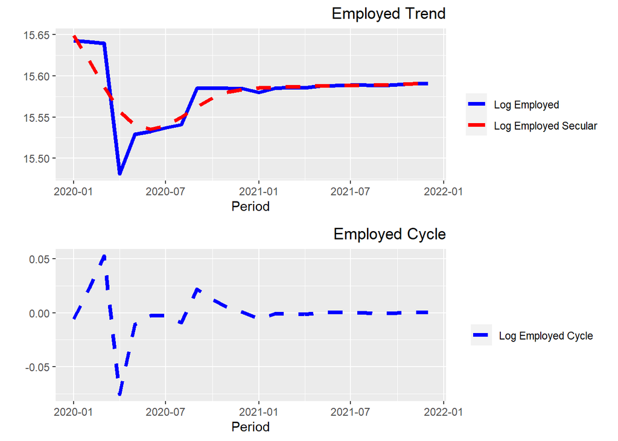

```r
plot_grid(plot91, plot92,ncol = 1,align = 'v')
```

#RHODE ISLAND

```r
lf_states44 <- filter(lf_states, Year != 2019, State == 44, early == 0)
lf_states44_6.25 <- hpfilter(lf_states44$lEmp , freq = 6.25,type = "lambda")
lf_states44$Emp_T6.25 <- lf_states44_6.25$trend
lf_states44$Emp_C6.25 <- lf_states44_6.25$cycle
plot93<-ggplot(data=lf_states44)+
geom_line(aes(x=Period,y=lEmp,color='Log Employed'),size=1.5) + geom_line(aes(x=Period,y=Emp_T6.25,color='Log Employed Secular'),linetype=2,size=1.5) +xlab("Period")+ylab("")+scale_colour_manual(name="",values=c('Log Employed'='blue','Log Employed Secular'='red'))+ggtitle('Employed Trend')+theme(plot.title = element_text(hjust = 1))

plot94<-ggplot(data=lf_states44)+
geom_line(aes(x=Period,y=Emp_C6.25,color='Log Employed Cycle'),size=1.5,linetype=2)  +xlab("Period")+ylab("")+scale_colour_manual(name="",values=c('Log Employed Cycle'='blue'))+ggtitle('Employed Cycle')+theme(plot.title = element_text(hjust = 1))
```

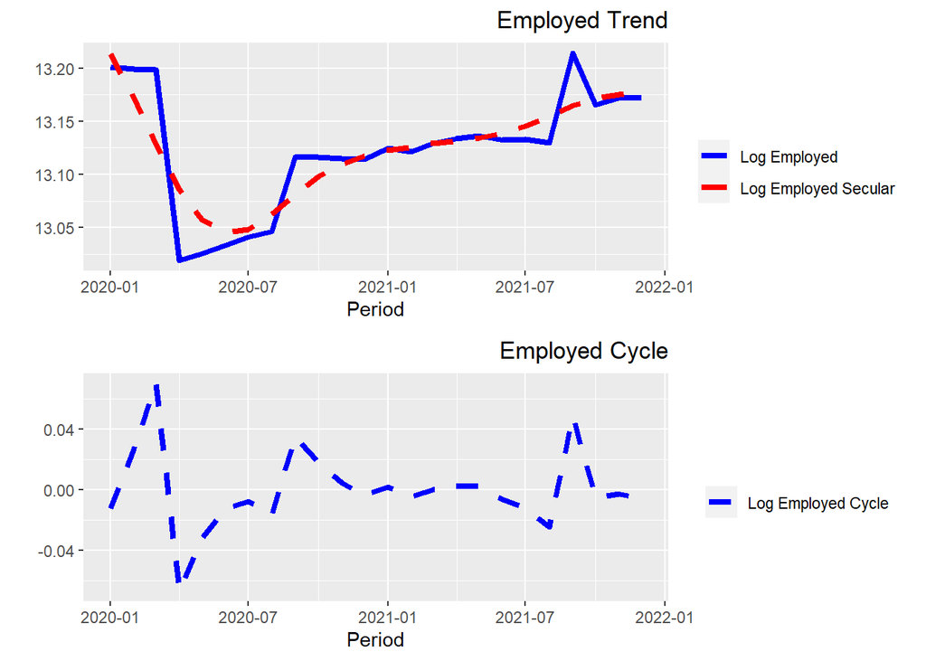

```r
plot_grid(plot93, plot94,ncol = 1,align = 'v')
```

#VERMONT

```r
lf_states50 <- filter(lf_states, Year != 2019, State == 50, early == 0)
lf_states50_6.25 <- hpfilter(lf_states50$lEmp , freq = 6.25,type = "lambda")
lf_states50$Emp_T6.25 <- lf_states50_6.25$trend
lf_states50$Emp_C6.25 <- lf_states50_6.25$cycle
plot95<-ggplot(data=lf_states50)+
geom_line(aes(x=Period,y=lEmp,color='Log Employed'),size=1.5) + geom_line(aes(x=Period,y=Emp_T6.25,color='Log Employed Secular'),linetype=2,size=1.5) +xlab("Period")+ylab("")+scale_colour_manual(name="",values=c('Log Employed'='blue','Log Employed Secular'='red'))+ggtitle('Employed Trend')+theme(plot.title = element_text(hjust = 1))

plot96<-ggplot(data=lf_states50)+
geom_line(aes(x=Period,y=Emp_C6.25,color='Log Employed Cycle'),size=1.5,linetype=2)  +xlab("Period")+ylab("")+scale_colour_manual(name="",values=c('Log Employed Cycle'='blue'))+ggtitle('Employed Cycle')+theme(plot.title = element_text(hjust = 1))
```

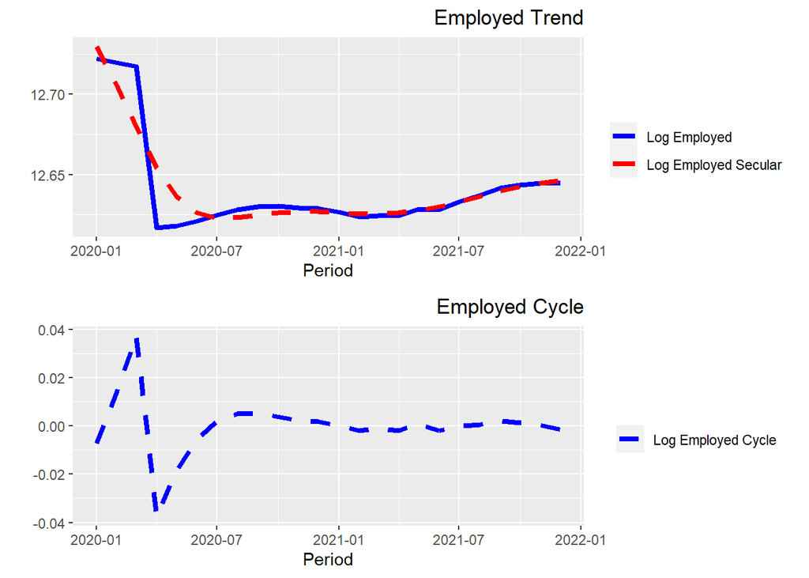

```r
plot_grid(plot95, plot96,ncol = 1,align = 'v')
```

#VIRGINIA

```r
lf_states51 <- filter(lf_states, Year != 2019, State == 51, early == 0)
lf_states51_6.25 <- hpfilter(lf_states51$lEmp , freq = 6.25,type = "lambda")
lf_states51$Emp_T6.25 <- lf_states51_6.25$trend
lf_states51$Emp_C6.25 <- lf_states51_6.25$cycle
plot97<-ggplot(data=lf_states51)+
geom_line(aes(x=Period,y=lEmp,color='Log Employed'),size=1.5) + geom_line(aes(x=Period,y=Emp_T6.25,color='Log Employed Secular'),linetype=2,size=1.5) +xlab("Period")+ylab("")+scale_colour_manual(name="",values=c('Log Employed'='blue','Log Employed Secular'='red'))+ggtitle('Employed Trend')+theme(plot.title = element_text(hjust = 1))

plot98<-ggplot(data=lf_states51)+
geom_line(aes(x=Period,y=Emp_C6.25,color='Log Employed Cycle'),size=1.5,linetype=2)  +xlab("Period")+ylab("")+scale_colour_manual(name="",values=c('Log Employed Cycle'='blue'))+ggtitle('Employed Cycle')+theme(plot.title = element_text(hjust = 1))
```

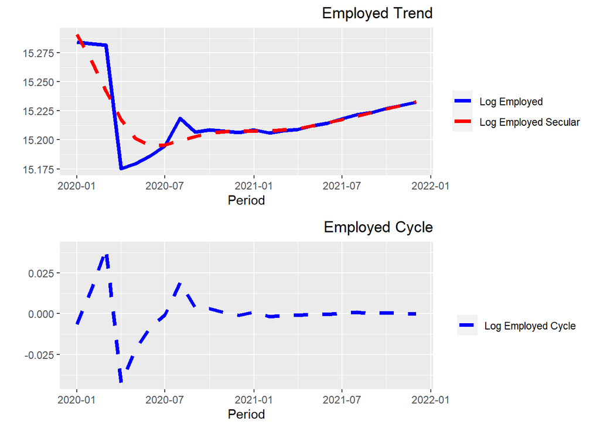

```r
plot_grid(plot97, plot98,ncol = 1,align = 'v')
```

#WASHINGTON

```r
lf_states53 <- filter(lf_states, Year != 2019, State == 53, early == 0)
lf_states53_6.25 <- hpfilter(lf_states53$lEmp , freq = 6.25,type = "lambda")
lf_states53$Emp_T6.25 <- lf_states53_6.25$trend
lf_states53$Emp_C6.25 <- lf_states53_6.25$cycle
plot99<-ggplot(data=lf_states53)+
geom_line(aes(x=Period,y=lEmp,color='Log Employed'),size=1.5) + geom_line(aes(x=Period,y=Emp_T6.25,color='Log Employed Secular'),linetype=2,size=1.5) +xlab("Period")+ylab("")+scale_colour_manual(name="",values=c('Log Employed'='blue','Log Employed Secular'='red'))+ggtitle('Employed Trend')+theme(plot.title = element_text(hjust = 1))

plot100<-ggplot(data=lf_states53)+
geom_line(aes(x=Period,y=Emp_C6.25,color='Log Employed Cycle'),size=1.5,linetype=2)  +xlab("Period")+ylab("")+scale_colour_manual(name="",values=c('Log Employed Cycle'='blue'))+ggtitle('Employed Cycle')+theme(plot.title = element_text(hjust = 1))
```

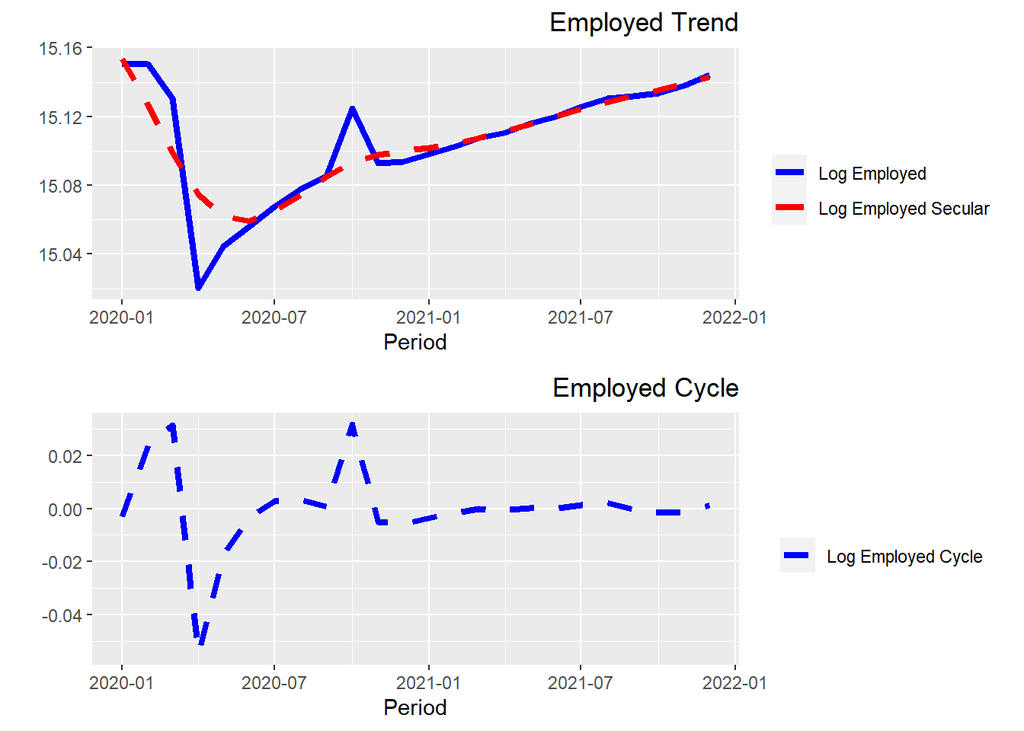

```r
plot_grid(plot99, plot100,ncol = 1,align = 'v')
```

#WISCONSIN

```r
lf_states55 <- filter(lf_states, Year != 2019, State == 55, early == 0)
lf_states55_6.25 <- hpfilter(lf_states55$lEmp , freq = 6.25,type = "lambda")
lf_states55$Emp_T6.25 <- lf_states55_6.25$trend
lf_states55$Emp_C6.25 <- lf_states55_6.25$cycle
plot101<-ggplot(data=lf_states55)+
geom_line(aes(x=Period,y=lEmp,color='Log Employed'),size=1.5) + geom_line(aes(x=Period,y=Emp_T6.25,color='Log Employed Secular'),linetype=2,size=1.5) +xlab("Period")+ylab("")+scale_colour_manual(name="",values=c('Log Employed'='blue','Log Employed Secular'='red'))+ggtitle('Employed Trend')+theme(plot.title = element_text(hjust = 1))

plot102<-ggplot(data=lf_states55)+
geom_line(aes(x=Period,y=Emp_C6.25,color='Log Employed Cycle'),size=1.5,linetype=2)  +xlab("Period")+ylab("")+scale_colour_manual(name="",values=c('Log Employed Cycle'='blue'))+ggtitle('Employed Cycle')+theme(plot.title = element_text(hjust = 1))
```

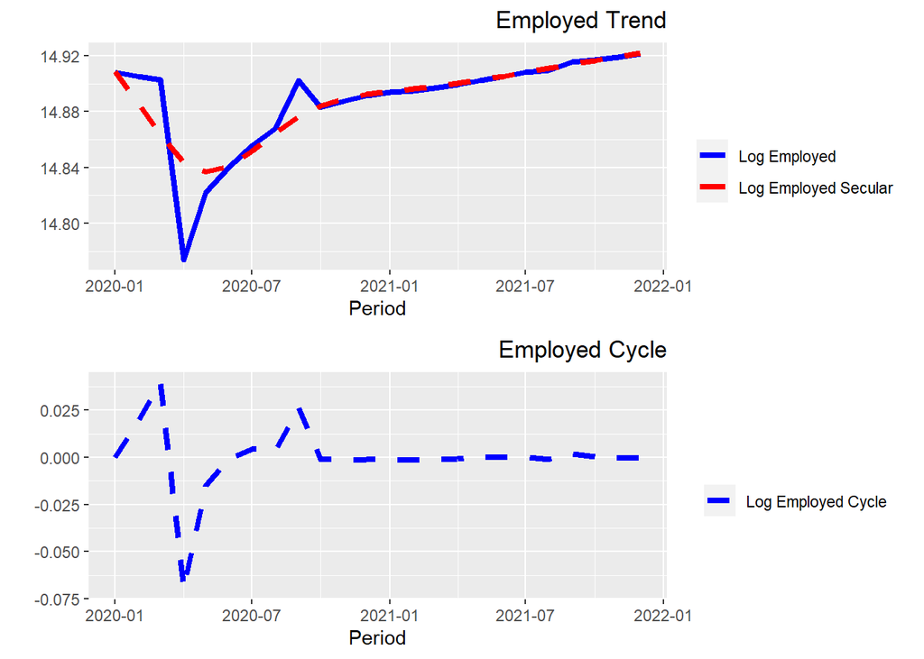

```r
plot_grid(plot101, plot102,ncol = 1,align = 'v')
```

#After the disscussion we need some exploratory analysis, so we pick another data set that has other Policy in it. #“COVID-19 US state policy database 3_3_2022”is the data set with all policies implemented over 50 states. #And “Combined” is the cleaned data set I used above, I export the data set for convenience.

```r
project_path <- "C:/Users/85384/Desktop/Capstone/GitHub/Capstone_4th_Economy"
setwd(project_path)
sp <- read_excel("COVID-19 US state policy database 3_3_2022.xlsx")

project_path <- "C:/Users/85384/Desktop/Capstone/GitHub/Capstone_4th_Economy"
setwd(project_path)
Combined <- read.csv("Combined.csv")
```

```r
View(sp)
#View(Combined)
```

```r
Combined[is.na(Combined)] <- 0
#View(Combined)
```

#Set up the dummy variable for the states moratorium on evictions now and let those states equal 1

```r
Combined$EMStatus <- ifelse(Combined$FIPS %in% c('6','9','11','15','17','24','25','27','34','35','36','37','41','50','53'),1,0)
#View(Combined)
```

#pick year 2020

```r
Combined20 <- filter(Combined, Year == 2020, Month >= 2, Month <= 8)
View(Combined20)
```

```r
count(Combined20, State)
```

```
##                   State n
## 1               Alabama 7
## 2                Alaska 7
## 3               Arizona 7
## 4              Arkansas 7
## 5            California 7
## 6              Colorado 7
## 7           Connecticut 7
## 8              Delaware 7
## 9  District of Columbia 7
## 10              Florida 7
## 11              Georgia 7
## 12               Hawaii 7
## 13                Idaho 7
## 14             Illinois 7
```

[output cut: 37 more lines]

```r
Prep <- Combined20 %>% group_by(FIPS, Month, State, CLDAYCR) %>%
    summarise(Emp = sum(Total.E),Claims = sum(InitialClaims),Case = sum(case_count),Death = sum(death_count),Vaccine = sum(fullvaccine_count),Hospitalized = sum(hospitalized_count))
#View(Prep)
```

```r
head(Prep)
```

```
## # A tibble: 6 x 10
## # Groups:   FIPS, Month, State [6]
##    FIPS Month State   CLDAYCR     Emp Claims  Case Death Vaccine Hospitalized
##   <int> <int> <chr>     <dbl>   <int>  <int> <int> <int>   <int>        <int>
## 1     1     2 Alabama       0 2177852   7573     0     0       0            0
## 2     1     3 Alabama       1 2176275 150556   740    10       0          150
## 3     1     4 Alabama       1 1899019 300079  5842   230       0        11333
## 4     1     5 Alabama       1 2044109 106301  9946   362       0        13027
## 5     1     6 Alabama       0 2049715  82914 18523   318       0        24295
## 6     1     7 Alabama       0 2056348  82427 47568   601       0        50006
```

```r
print(Prep)
```

```
## # A tibble: 357 x 10
## # Groups:   FIPS, Month, State [357]
##     FIPS Month State   CLDAYCR     Emp Claims  Case Death Vaccine Hospitalized
##    <int> <int> <chr>     <dbl>   <int>  <int> <int> <int>   <int>        <int>
##  1     1     2 Alabama       0 2177852   7573     0     0       0            0
##  2     1     3 Alabama       1 2176275 150556   740    10       0          150
##  3     1     4 Alabama       1 1899019 300079  5842   230       0        11333
##  4     1     5 Alabama       1 2044109 106301  9946   362       0        13027
##  5     1     6 Alabama       0 2049715  82914 18523   318       0        24295
##  6     1     7 Alabama       0 2056348  82427 47568   601       0        50006
##  7     1     8 Alabama       0 2061877  41797 39531   594       0        53634
##  8     2     2 Alaska        0  335023   3580     0     0       0            0
##  9     2     3 Alaska        0  334331  30261    98     1       0           26
## 10     2     4 Alaska        0  304991  49769   246     0       0          438
## # ... with 347 more rows
```

```r
str(Prep)
```

[output not shown]

[output cut: 63 more lines]

[output not shown]

```r
#cldaycr <- filter(Prep, CLDAYCR == 1)
cldaycr <- Prep[c(1:7,50:56,92:98,120:126,141:147,148:161,211:217,246:252,260:280,337:343,351:357),]
#states never closed day care
ncl <- Prep[-c(1:7,50:56,92:98,120:126,141:147,148:161,211:217,246:252,260:280,337:343,351:357),]
view(cldaycr)
View(ncl)
count(cldaycr,Month)
```

```
## # A tibble: 98 x 4
## # Groups:   FIPS, Month, State [98]
##     FIPS Month State        n
##    <int> <int> <chr>    <int>
##  1     1     2 Alabama      1
##  2     1     3 Alabama      1
##  3     1     4 Alabama      1
##  4     1     5 Alabama      1
##  5     1     6 Alabama      1
##  6     1     7 Alabama      1
##  7     1     8 Alabama      1
##  8    10     2 Delaware     1
##  9    10     3 Delaware     1
## 10    10     4 Delaware     1
## # ... with 88 more rows
```

```r
cldaycr <- cldaycr[,-c(3)]
```

```r
cldaycr3 <- filter(cldaycr, Month == 3)
cldaycr4 <- filter(cldaycr, Month == 4)
cldaycr5 <- filter(cldaycr, Month == 5)
cldaycr6 <- filter(cldaycr, Month == 6)
colMeans(cldaycr3,na.rm=TRUE)
```

```
##         FIPS        Month      CLDAYCR          Emp       Claims         Case
## 3.100000e+01 3.000000e+00 3.571429e-01 3.002930e+06 2.779846e+05 2.269786e+03
##        Death      Vaccine Hospitalized
## 3.642857e+01 0.000000e+00 3.414286e+02
```

```r
colMeans(cldaycr4,na.rm=TRUE)
```

```
##         FIPS        Month      CLDAYCR          Emp       Claims         Case
##       31.000        4.000        1.000  2506246.429   344802.571    23370.714
##        Death      Vaccine Hospitalized
##     1365.429        0.000    26905.571
```

```r
colMeans(cldaycr5,na.rm=TRUE)
```

```
##         FIPS        Month      CLDAYCR          Emp       Claims         Case
## 3.100000e+01 5.000000e+00 8.571429e-01 2.620765e+06 1.376828e+05 2.010557e+04
##        Death      Vaccine Hospitalized
## 1.510929e+03 0.000000e+00 4.033236e+04
```

```r
colMeans(cldaycr6,na.rm=TRUE)
```

```
##         FIPS        Month      CLDAYCR          Emp       Claims         Case
## 3.100000e+01 6.000000e+00 2.142857e-01 2.703665e+06 1.021684e+05 1.062443e+04
##        Death      Vaccine Hospitalized
## 7.853571e+02 0.000000e+00 2.468829e+04
```

```r
ncl <- ncl[,-c(3)]
```

```r
ncl3 <- filter(ncl, Month == 3)
ncl4 <- filter(ncl, Month == 4)
ncl5 <- filter(ncl, Month == 5)
ncl6 <- filter(ncl, Month == 6)
colMeans(ncl3,na.rm=TRUE)
```

```
##         FIPS        Month      CLDAYCR          Emp       Claims         Case
## 2.818919e+01 3.000000e+00 0.000000e+00 3.090688e+06 2.100798e+05 2.519865e+03
##        Death      Vaccine Hospitalized
## 5.245946e+01 0.000000e+00 7.942432e+02
```

```r
colMeans(ncl4,na.rm=TRUE)
```

```
##         FIPS        Month      CLDAYCR          Emp       Claims         Case
## 2.818919e+01 4.000000e+00 0.000000e+00 2.674748e+06 3.414646e+05 1.458227e+04
##        Death      Vaccine Hospitalized
## 9.510811e+02 0.000000e+00 2.596986e+04
```

```r
colMeans(ncl5,na.rm=TRUE)
```

```
##         FIPS        Month      CLDAYCR          Emp       Claims         Case
## 2.818919e+01 5.000000e+00 0.000000e+00 2.730316e+06 1.949662e+05 1.230500e+04
##        Death      Vaccine Hospitalized
## 6.322432e+02 0.000000e+00 2.837373e+04
```

```r
colMeans(ncl6,na.rm=TRUE)
```

```
##         FIPS        Month      CLDAYCR          Emp       Claims         Case
## 2.818919e+01 6.000000e+00 0.000000e+00 2.816985e+06 1.396824e+05 1.725484e+04
##        Death      Vaccine Hospitalized
## 3.434865e+02 0.000000e+00 2.505695e+04
```

```r
df <- data.frame (Period = c("2020/3/15","2020/4/15","2020/5/15","2020/6/15"),
                  Emp1  = c("3002929.7142857", "2506246.429 ", "2620765.2142857","2703665.1428571"),
                  Emp2 = c("3090687.94595", "2674748.32432", "2730316.13514","2816985.45946"),
                  Claims1 = c("277984.5714286","23370.714","137682.7857143 ","102168.4285714"),
                  Claims2 = c("210079.83784","341464.59459","194966.16216","139682.40541 "),
                  Case1 = c("2269.7857143","23370.714","20105.5714286","10624.4285714"),
                  Case2 = c("2519.86486","14582.27027","12305","17254.83784"),
                  Death1 = c("36.4285714","1365.429","1510.9285714","785.3571429"),
                  Death2 = c("52.45946","951.08108","632.24324","343.48649"),
                  Hospitalized1 = c("341.4285714","26905.571","40332.3571429","24688.2857143"),
                  Hospitalized2 = c("794.24324","25969.86486","28373.72973","25056.94595"))
df$Period <- as.Date(df$Period)
df$Emp1 <- as.numeric(df$Emp1)
df$Emp2 <- as.numeric(df$Emp2)
df$Claims1 <- as.numeric(df$Claims1)
df$Claims2 <- as.numeric(df$Claims2)
df$Case1 <- as.numeric(df$Case1)
df$Case2 <- as.numeric(df$Case2)
df$Death1 <- as.numeric(df$Death1)
df$Death2 <- as.numeric(df$Death2)
df$Hospitalized1 <- as.numeric(df$Hospitalized1)
df$Hospitalized2 <- as.numeric(df$Hospitalized2)
View(df)
```

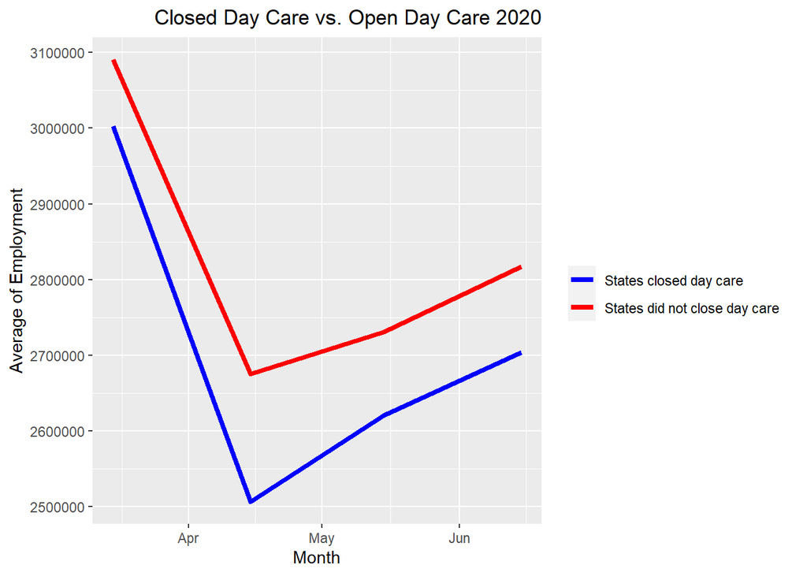

```r
plot103<-ggplot(data=df)+
geom_line(aes(x=Period,y=Emp1,color='States closed day care'),size=1.5) + geom_line(aes(x=Period,y=Emp2,color='States did not close day care'),size=1.5) +xlab("Month")+ylab("Average of Employment")+scale_colour_manual(name="",values=c('States closed day care'='blue','States did not close day care'='red'))+ggtitle('Closed Day Care vs. Open Day Care 2020')+theme(plot.title = element_text(hjust = 1))

plot_grid(plot103,ncol = 1,align = 'v')
```

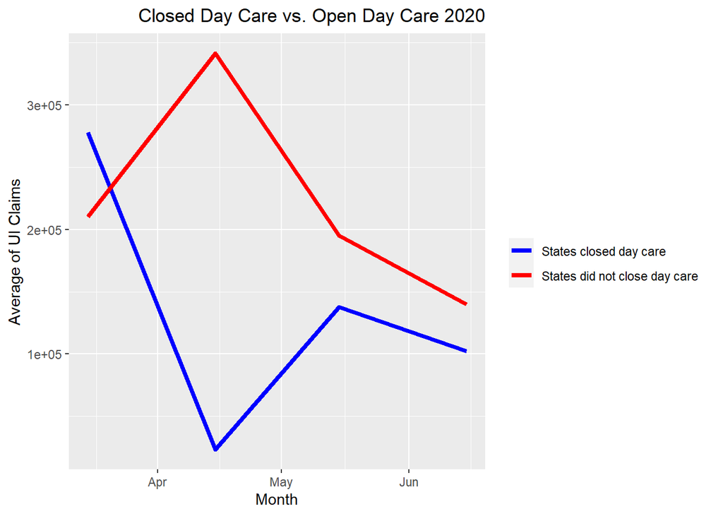

```r
plot104<-ggplot(data=df)+
geom_line(aes(x=Period,y=Claims1,color='States closed day care'),size=1.5) + geom_line(aes(x=Period,y=Claims2,color='States did not close day care'),size=1.5) +xlab("Month")+ylab("Average of UI Claims")+scale_colour_manual(name="",values=c('States closed day care'='blue','States did not close day care'='red'))+ggtitle('Closed Day Care vs. Open Day Care 2020')+theme(plot.title = element_text(hjust = 1))

plot_grid(plot104,ncol = 1,align = 'v')
```

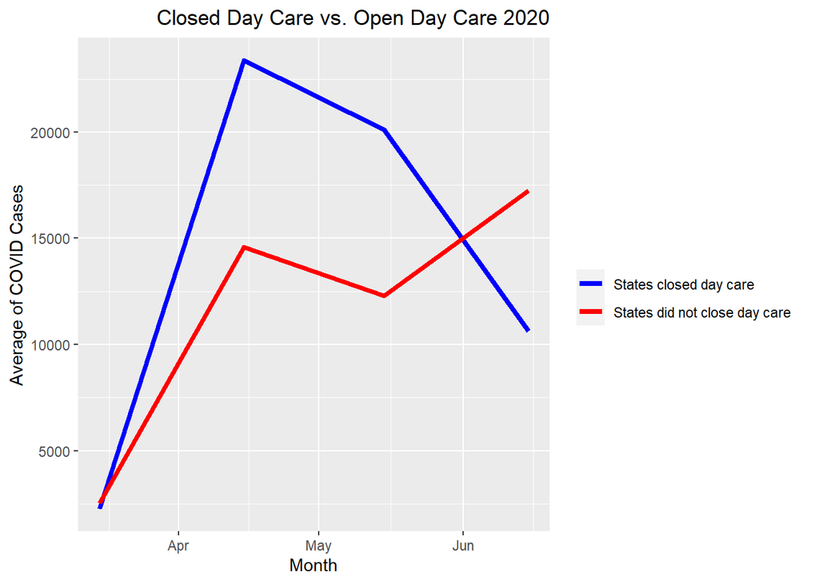

```r
plot105<-ggplot(data=df)+
geom_line(aes(x=Period,y=Case1,color='States closed day care'),size=1.5) + geom_line(aes(x=Period,y=Case2,color='States did not close day care'),size=1.5) +xlab("Month")+ylab("Average of COVID Cases")+scale_colour_manual(name="",values=c('States closed day care'='blue','States did not close day care'='red'))+ggtitle('Closed Day Care vs. Open Day Care 2020')+theme(plot.title = element_text(hjust = 1))

plot_grid(plot105,ncol = 1,align = 'v')
```

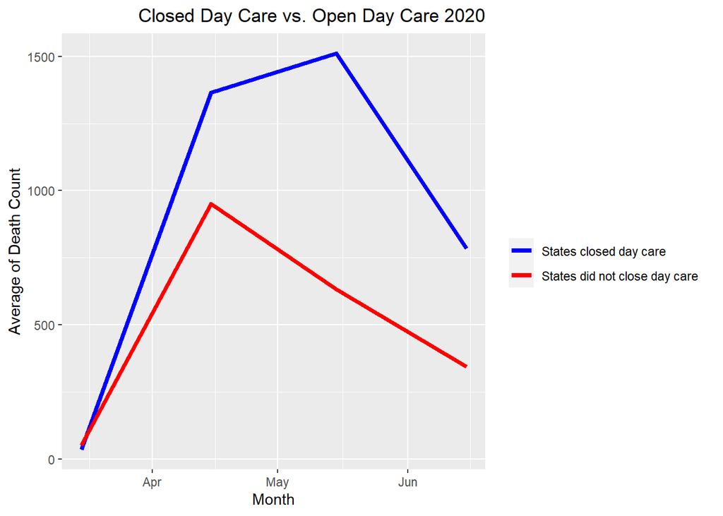

```r
plot106<-ggplot(data=df)+
geom_line(aes(x=Period,y=Death1,color='States closed day care'),size=1.5) + geom_line(aes(x=Period,y=Death2,color='States did not close day care'),size=1.5) +xlab("Month")+ylab("Average of Death Count")+scale_colour_manual(name="",values=c('States closed day care'='blue','States did not close day care'='red'))+ggtitle('Closed Day Care vs. Open Day Care 2020')+theme(plot.title = element_text(hjust = 1))

plot_grid(plot106,ncol = 1,align = 'v')
```

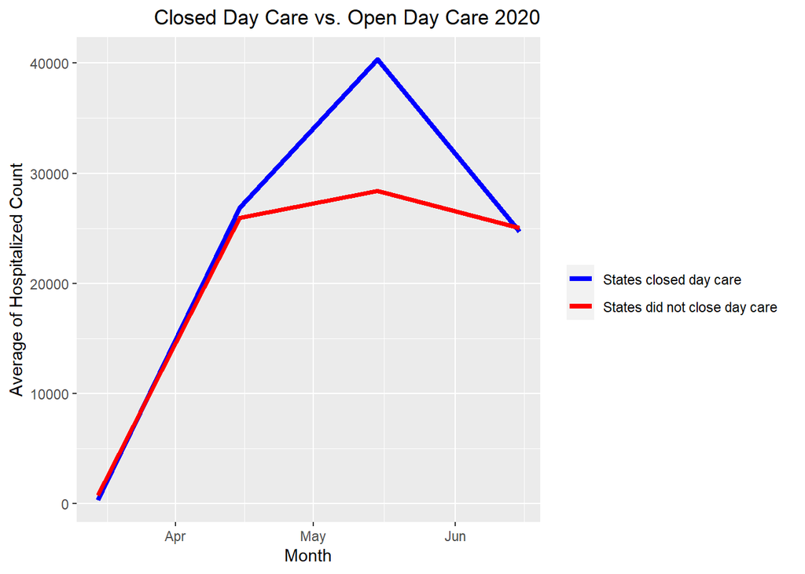

```r
plot107<-ggplot(data=df)+
geom_line(aes(x=Period,y=Hospitalized1,color='States closed day care'),size=1.5) + geom_line(aes(x=Period,y=Hospitalized2,color='States did not close day care'),size=1.5) +xlab("Month")+ylab("Average of Hospitalized Count")+scale_colour_manual(name="",values=c('States closed day care'='blue','States did not close day care'='red'))+ggtitle('Closed Day Care vs. Open Day Care 2020')+theme(plot.title = element_text(hjust = 1))

plot_grid(plot107,ncol = 1,align = 'v')
```

```r
project_path <- "C:/Users/85384/Desktop/Capstone/GitHub/Capstone_4th_Economy"
setwd(project_path)
compare <- read.csv("numbers (1).csv")
View(compare)
compare <- subset(compare, select = -c(16:18))
compare <- compare[-c(193:220), ]
```

```r
compare$Deaths_RollingAvg  <- as.numeric(compare$Deaths_RollingAvg)
compare$Hosp_Admissions_RollingAvg  <- as.numeric(compare$Hosp_Admissions_RollingAvg)
compare$Deaths_RollingAvg[is.na(compare$Deaths_RollingAvg)] <- mean(compare$Deaths_RollingAvg, na.rm=TRUE)
compare$Hosp_Admissions_RollingAvg[is.na(compare$Hosp_Admissions_RollingAvg)] <- mean(compare$Hosp_Admissions_RollingAvg, na.rm=TRUE)
compare[is.na(compare)] <- 0
compare$state_indicator <- ifelse(compare$ï..StateFIPS %in% c('39'),1,0)
compare$Date <- as.Date(compare$Date,"%m/%d/%Y")
class(compare$Date)
```

```
## [1] "Date"
```

```r
View(compare)
```

```r
reg1 <- felm(compare$LaborForce ~ compare$Cases_RollingAvg + compare$Hosp_Admissions_RollingAvg)

#reg2 <- felm(compare$Employment ~ compare$Cases_RollingAvg + compare$Hosp_Admissions_RollingAvg)

reg3 <- felm(compare$Unemployment ~ compare$Cases_RollingAvg + compare$Hosp_Admissions_RollingAvg)

reg4 <- felm(compare$Unemployment_rate ~ compare$Cases_RollingAvg + compare$Hosp_Admissions_RollingAvg)

reg5 <- felm(compare$UI_Claims ~ compare$Cases_RollingAvg + compare$Hosp_Admissions_RollingAvg)
```

==================================================================================================== Economic Terms  
——————————————————— Labor Force Unemployment Unemployment Rate UI Claims  
(1) (2) (3) (4)  
—————————————————————————————————- Case Rolling Average -44.073 -36.161*** -0.054*** -75.346**  
(59.473) (8.575) (0.009) (29.122)

Hospitalization Admissions Rolling Average 2,280.274*** 283.945*** 0.230*** 534.848**  
(487.333) (70.264) (0.075) (238.628)

Constant 54,341.900*** 5,132.008*** 8.999*** 5,568.195*** (1,930.133) (278.289) (0.296) (945.112)

Observations 192 192 192 192  
R2 0.175 0.093 0.175 0.035  
Adjusted R2 0.167 0.084 0.166 0.025  
Residual Std. Error (df = 189) 20,850.020 3,006.185 3.199 10,209.450 ==================================================================================================== Significance Levels *p<0.1; **p<0.05;*** p<0.01

```r
data_Ohio <- compare %>% filter(compare$state_indicator == 1, compare$CountyFIPS == 155)
data_Penn <- compare %>% filter(compare$state_indicator == 0, compare$CountyFIPS == 85)
data <- rbind(data_Ohio, data_Penn)
View(data)
#data_mean<-data %>%
  #group_by(states_indicaor) %>%
#dplyr::summarize(prebinmean = mean(Uneployment_rate, na.rm=TRUE),
                 #treatbinmean = mean(UI_Policy, na.rm=TRUE))
#View(data_mean)
```

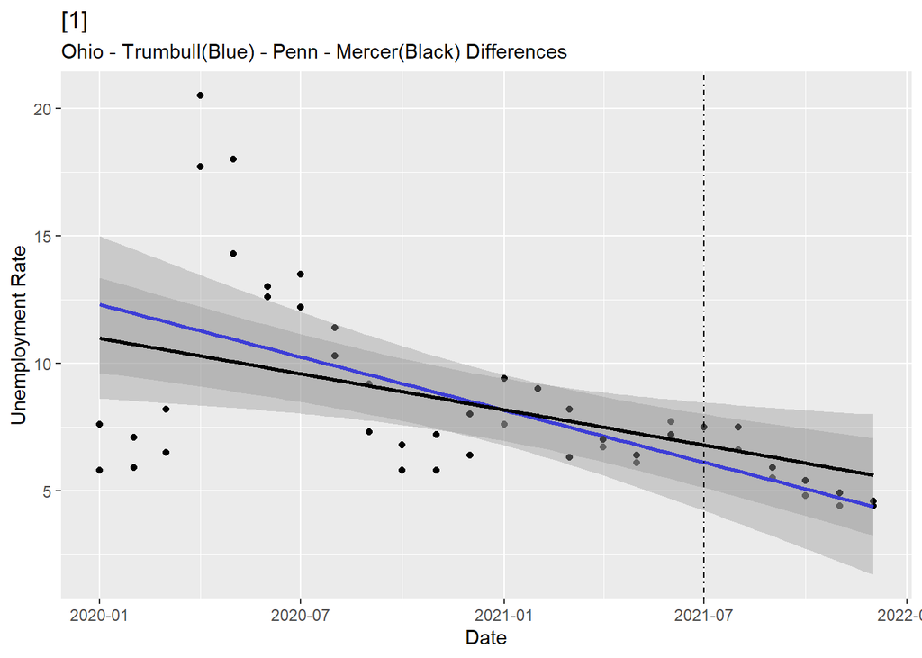

```r
plot108 <- ggplot() +
  geom_point(data_Ohio, mapping = aes(x=Date, y=Unemployment_rate)) + geom_smooth(data_Ohio, mapping = aes(x=Date, y=Unemployment_rate), method = lm, se = TRUE, color = "Blue")+
  geom_point(data_Penn, mapping = aes(x=Date, y=Unemployment_rate)) + geom_smooth(data_Penn, mapping = aes(x=Date, y=Unemployment_rate), method = lm, se = TRUE, color = "Black")+
  geom_vline(xintercept = as.numeric(as.Date("2021-07-01")), linetype=4) + ylab("Unemployment Rate")+xlab("Date") + ggtitle(size_sum(0.5), "Ohio - Trumbull(Blue) - Penn - Mercer(Black) Differences")
plot108
```

```r
#reg6 <- felm()
```